# Исследование отзывов пользователей Skytrax

Логанова Наталья

## Задача

на основе данных (и выданных вопросов) постараться выяснить:

- какие проблемы есть в авиаперевозках
- какие улучшения можно предложить на основе выводов по данным

#### Вопросы

```r
library(dplyr)
library(ggplot2)

source("~/shared/minor2_2022/1-Intro/hw1/hw1_data.R")

airline = hw1_get_data(df_name = "airline")
airport = hw1_get_data(df_name = "airport")
lounge = hw1_get_data(df_name = "lounge")
seat = hw1_get_data(df_name = "seat")

hw1_get_questions()
```

| id | questions |
| --- | --- |
| 1 | -Какие типы путешественников (type_traveller) поставили самые высокие оценки за еду на борту? |
| 2 | -В каких самолетах более высокие оценки удобства пространства для ног — те, в которых два прохода или один? |
| 3 | -Какие лаунж-зоны оценены по чистоте (cleanliness) выше, чем аэропорты, в которых они расположены? |

#### Вопрос 1

**Вопрос:** Какие типы путешественников (type_traveller) поставили самые высокие оценки за еду на борту?

**Данные:** Для ответа на вопрос нужна таблица airline.

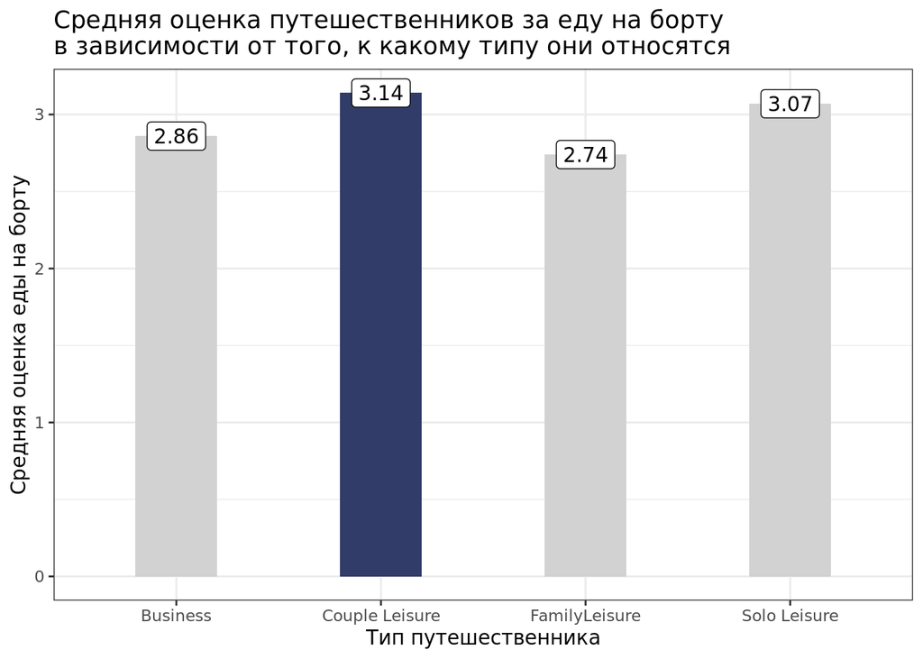

```r
# код для ответа на вопрос 1:

foodrating = airline %>%
  filter (!is.na(type_traveller)) %>%
  filter (!is.na(food_beverages_rating))

#после удаления пустых строк осталось 110 наблюдений из 2244. чтобы понять, имеет ли смысл дальнейший анализ, проверим репрезентативность выборки по стране автора (author_country) и тому, каким классом они летали (cabin_flown)

t1 = arrange (count(airline, author_country), n)
t2 = arrange (count(foodrating, author_country), n)

#по стране распределение близко к генеральной совокупности, хотя есть маленькие несоответствия

t3 = arrange (count(airline, cabin_flown), n)
t4 = arrange (count(foodrating, cabin_flown), n)

#по классу кабины проценты разных классов в генеральной и выборочной выборках совпадают. значит, имеет смысл провести анализ на 110 наблюдений, так как все группы, присутствующие в совокупности, представлены и в выборке

foodrating = group_by(foodrating, type_traveller)
food = dplyr::summarise(foodrating, meanrating = round(mean(food_beverages_rating), 2))

#построение графика

ggplot() +
  geom_bar(data = food, aes(x = type_traveller, y = meanrating), stat = "identity", fill = "#D2D2D2", width = 0.4) +
  xlab("Тип путешественника") +
  ylab ("Средняя оценка еды на борту") +
  ggtitle("Средняя оценка путешественников за еду на борту \nв зависимости от того, к какому типу они относятся") +
  theme_bw() +
  geom_bar(top_n(food, meanrating, n=1), mapping = aes(x = type_traveller, y = meanrating), stat = "identity", fill = "#323C69", width = 0.4) +
  geom_label (data = food, aes(x = type_traveller, y = meanrating, label = meanrating))
```

**Ответ:** Самую высокую оценку за еду на борту поставили путешественники типа Couple Leisure. Затем Solo Leisure, Business и FamilyLeisure.

**Вывод:** На основе этого результата можно сделать вывод о том, что пары-путешественники являются более позитивными, если считать, что еда одинаковая. Однако еда у разных классов обычно отличается, поэтому нужно отдельно изучать каждый класс. Результаты того, какой тип оценивает еду более высоко по сравнению с другими, поможет понять, какие путешественники являются более позитивным или негативными. Позитивность/негативность определенных групп может искажать результаты других исследований, понижая уровень объективности выводов.

#### Вопрос 2

**Вопрос:** В каких самолетах более высокие оценки удобства пространства для ног — те, в которых два прохода или один?

**Данные:** Для ответа на вопрос нужна таблица seat.

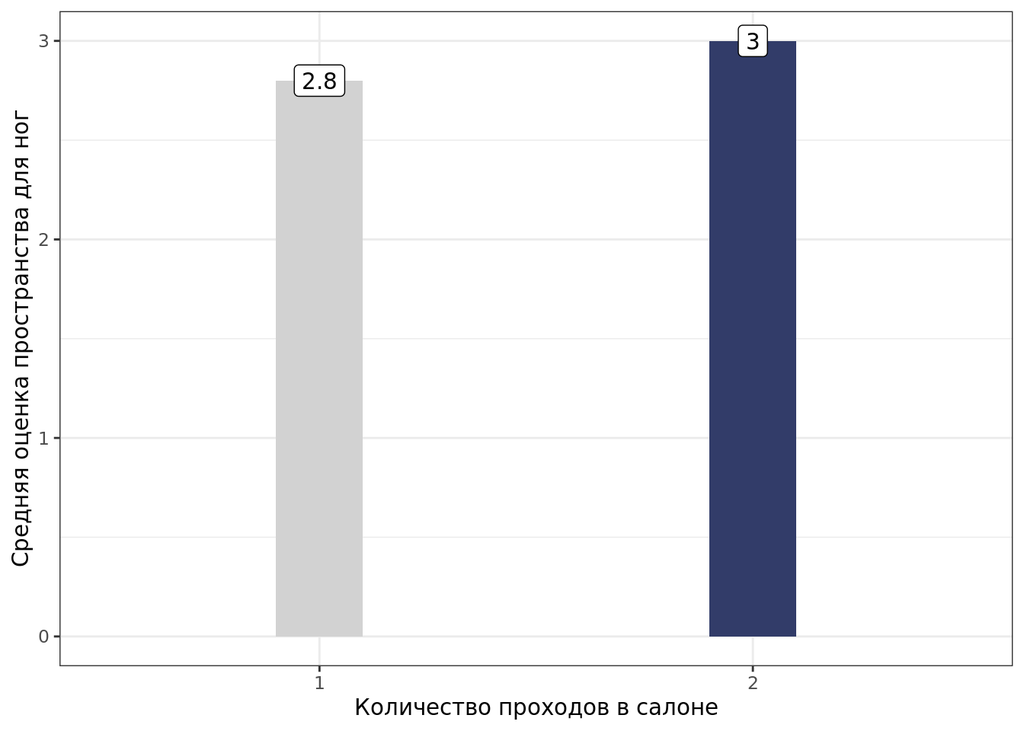

```r
# код для ответа на вопрос 2:

legroom_rating = select(seat,seat_layout,seat_legroom_rating)
legroom_rating$seat_layout = str_replace_all(legroom_rating$seat_layout,"3X3", "3x3")
legroom_rating$seat_layout = str_replace_all(legroom_rating$seat_layout,"3-3","3x3")
legroom_rating = legroom_rating[-c(35), ]
legroom_rating = mutate(legroom_rating, number_of_passages = str_count(seat_layout,"x"))

legroom_rating = group_by(legroom_rating, number_of_passages)
legroom_rating = dplyr::summarise(legroom_rating, mean_legroom_rating = round(mean(seat_legroom_rating),1))

#построение графика
ggplot() +
  geom_bar(data = legroom_rating, aes(x = format (number_of_passages), y = mean_legroom_rating), stat = "identity", fill = "#D2D2D2", width = 0.2) +
  xlab("Количество проходов в салоне") +
  ylab ("Средняя оценка пространства для ног") +
#  ggtitle("Зависимость удобства пространства для ног от количества проходов в салоне") +
  theme_bw() +
    geom_bar(top_n(legroom_rating, mean_legroom_rating, n=1), mapping = aes(x = format (number_of_passages), y = mean_legroom_rating), stat = "identity", fill = "#323C69", width = 0.2) +
  geom_label (data = legroom_rating, aes(x = format (number_of_passages), y = mean_legroom_rating, label = mean_legroom_rating))
```

**Ответ:** В самолетах с 2 проходами более высокие оценки удобства пространства для ног.

**Вывод:** Это значит, что для лучшей оценки клиентами авиакомпаниям стоит использовать самолеты с 2 проходами.

#### Вопрос 3

**Вопрос:** Какие лаунж-зоны оценены по чистоте (cleanliness) выше, чем аэропорты, в которых они расположены?

**Данные:** Для ответа на вопрос нужны таблицы airport и lounge.

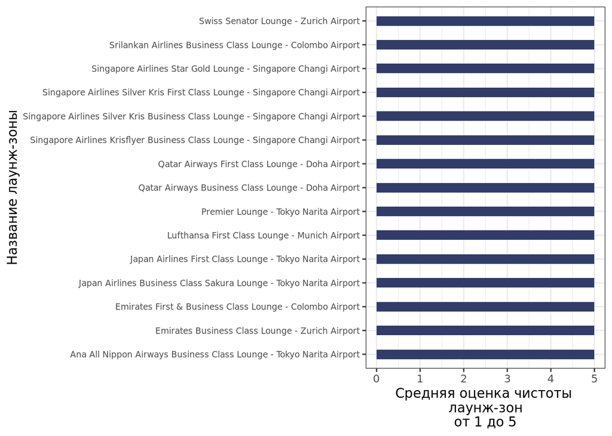

```r
# код для ответа на вопрос 3:

a_clean= select(airport, airport_name, terminal_cleanliness_rating)
a_clean$airport_name = str_replace_all(a_clean$airport_name,"-", " ")
a_clean$airport_name = str_to_title(a_clean$airport_name)
a_clean = rename(a_clean, airport = airport_name)
a_clean = a_clean %>%
  filter (!is.na(terminal_cleanliness_rating))
a_clean = a_clean %>%
  filter (!is.na(airport))

l_clean= select(lounge, airport, title, cleanliness_rating)
l_clean$airport = str_replace_all(l_clean$airport,"-", " ")
l_clean$airport = str_to_title(l_clean$airport)
l_clean = l_clean %>%
  filter (!is.na(cleanliness_rating))
l_clean = l_clean %>%
  filter (!is.na(airport))
l_clean = rename(l_clean, lounge_cleanliness_rating = cleanliness_rating)
l_clean$title = str_to_title(l_clean$title)

a_clean = group_by(a_clean, airport)
a_clean = dplyr::summarise(a_clean, a_mean_clean_rating = round(mean(terminal_cleanliness_rating), 2))

l_clean = group_by(l_clean, airport, title)
l_clean = dplyr::summarise(l_clean, l_mean_clean_rating = round(mean(lounge_cleanliness_rating), 2))

la_clean = left_join(l_clean, a_clean, by="airport")
la_clean = unique(la_clean)
la_clean = la_clean %>%
  mutate(a = l_mean_clean_rating > a_mean_clean_rating)
la_clean = la_clean %>%
  filter(a == 1)

la_clean = arrange(la_clean, -l_mean_clean_rating)
la_clean = arrange(la_clean, -a_mean_clean_rating)

#мне кажется, что 2 и 4 строка про один лаунж, просто Silverkris написали по-разному, поэтому я удалю 4 строку
la_clean = la_clean[-c(4), ]

#так как у 84 одинаково самая высокая оценка по чистоте (5/5), поэтому я проранжирую по убыванию еще по средней оценке чистоты аэропортов. тогда получится 15 лаунж с самым высоким рейтингом по чистоте лаунжа и самого аэропорта. этот топ-15 я проиллюстрирую в столбчатой диаграмме.

top15clean = head (la_clean, 15)

#построение графика

ggplot()+
  geom_bar(data = top15clean, aes(x = title, y = l_mean_clean_rating), stat = "identity", fill = "#323C69", width = 0.4) +
  xlab("Название лаунж-зоны") +
  ylab ("Средняя оценка чистоты \nлаунж-зон\nот 1 до 5") +
#  ggtitle("Какие лаунж-зоны оценены по чистоте выше, \nчем аэропорты, в которых они расположены?") +
  theme_bw() +
  theme (axis.text.y = element_text(size = 7)) +
  coord_flip()
```

**Ответ:** Всего 162 лаунж-зон оценены по чистоте выше, чем аэропорты, в которых они находятся. Это 41% от всего числа лаунж-зон. У 84 из них высшая оценка по чистоте(5).

**Вывод:** По сути, лаунж-зоны должны быть чище, чем аэропорты в которых они находятся, потому что люди платят доп деньги (или что-то другое), чтобы войти туда. К тому же, у ограниченного количества людей есть доступ к лаунжам, поэтому легче поддерживать чистоту там. Однако 59% (это больше половины) лаунж-зон не оценены по чистоте выше, чем аэропорты в которых они находятся. Это значит, что:

1. либо лаунж-зоны по чистоте такие же или грязнее своих аэропортов (что очень маловероятно);
2. либо люди, которые посещают лаунж-зоны, ожидают более высокого уровня чистоты от лаунж-зон, так как, по определению, они премиальные. Из-за этого они разочаровываются и ставят оценку ниже.

Это значит, что аэропорты должны поддерживать более высокий уровень в лаунж-зонах, чтобы люди не переставали посещать их. Если для этого нужны финансы, можно увеличить цену прохода в лаунж, так как для премиального сектора различие на 5-10% от цены не слишком влияет. Далее, можно исследовать, влияет ли чистота на общий рейтинг.

### Дэшборд

Полученные выводы обобщены в виде дэшборда со следующими элементами

**Элемент 1:**

- вид: число
- ответ на вопрос: 3
- обоснование: чтобы показать долю лаунж-зон, которые оценены по чистоте выше, чем аэропорты, в которых они находятся

**Элемент 2:**

- вид: число
- ответ на вопрос: 2
- обоснование: чтобы показать количество самолетов с 2 проходами. это будет относиться к графику 2.

**Элемент 3:**

- вид: график
- ответ на вопрос: 3
- обоснование: перечислены лаунж-зоны со средней оценкой, поэтому я выбрала столбчатую диаграмму. это нужно показать, чтобы заказчик понял, что важно поддерживать чистоту в лаунж-зонах

**Элемент 4:**

- вид: график
- ответ на вопрос: 2
- обоснование: выбрана столбчатая диаграмма, так как нужно показать среднюю оценку для каждого вида (1 или 2 прохода). я решила показать это в дэшборде, потому что количество проходов влияет на оценку клиентов

### Общие выводы

В заключение можно сказать, что пары-путешественники наиболее позитивные при оценивании. Также самолеты с 2 проходами наиболее высоко оценены по удобстве пространства для ног. Более того, аэропортам важно поддерживать высокий уровень чистоты в лаунж-зонах.